# MA TranscriptionProfiling For HIV and HCV Mono-infected and Co-infected Individuals

Mehdi Merbah

10/14/2020

## Our Analysis

This is essentially a replication of the study. Our analysis however, is going to focus on finding DEGs between HIV and HCV mono-infected individuals only. The paired comparison results are later compared with the findings from the paper and highlighted.

## Loading the R packages

Loading packages

```r
suppressPackageStartupMessages({library("maEndToEnd")})
```

## Data importing and Storing

We have already downloaded the data and stored it in a local repository.

```r
raw_data_dir <-  '/home/mehdimerbah/Documents/Data'

sdrf_location <- file.path(raw_data_dir, "E-MEXP-3635.sdrf.txt")

SDRF <- read.delim(sdrf_location)

rownames(SDRF) <- SDRF$Array.Data.File

SDRF <- AnnotatedDataFrame(SDRF)

raw_data <- oligo::read.celfiles(filenames = file.path(raw_data_dir, SDRF$Array.Data.File),verbose = FALSE, phenoData = SDRF)
```

```
## Reading in : /home/mehdimerbah/Documents/Data/HCV1.CEL
## Reading in : /home/mehdimerbah/Documents/Data/HCV2.CEL
## Reading in : /home/mehdimerbah/Documents/Data/HCV3.CEL
## Reading in : /home/mehdimerbah/Documents/Data/HIV1.CEL
## Reading in : /home/mehdimerbah/Documents/Data/HIV2.CEL
## Reading in : /home/mehdimerbah/Documents/Data/HIV3.CEL
## Reading in : /home/mehdimerbah/Documents/Data/HCVHIV1.CEL
## Reading in : /home/mehdimerbah/Documents/Data/HCVHIV2.CEL
## Reading in : /home/mehdimerbah/Documents/Data/HCVHIV3.CEL
```

## Exploring The Data

We can now see the phenoData from the raw data file.

```r
head(Biobase::pData(raw_data), 1)
```

```
##          Source.Name Material.Type Characteristics.organism.      Provider
## HCV1.CEL       HCV-1 organism part              Homo sapiens Shen Zhen CDC
##          Characteristics.specimen.with.known.storage.state.
## HCV1.CEL                                     fresh specimen
##          Characteristics.developmental.stage. Characteristics.sex.
## HCV1.CEL                                adult                 male
##          Characteristics.age. Unit.time.unit. Characteristics.organism.part.
## HCV1.CEL             19 to 40            year                          blood
##          Characteristics.infect. Protocol.REF Sample.Name Material.Type.1
## HCV1.CEL       hepatitis C virus P-MTAB-26654       HCV-1            cell
##          Characteristics.cell.type. Protocol.REF.1 Protocol.REF.2 Extract.Name
## HCV1.CEL CD8-Positive T-Lymphocytes   P-MTAB-26653   P-MTAB-26655        HCV-1
##          Material.Type.2 Protocol.REF.3 LabeledExtract.Name  Label
## HCV1.CEL     genomic_DNA       P-AFFY-2               HCV-1 biotin
##                                     Protocol.REF.4 Hybridization.Name
## HCV1.CEL Affymetrix:Protocol:Hybridization-Unknown              HCV-1
##          Array.Design.REF Protocol.REF.5 Array.Data.File
## HCV1.CEL       A-AFFY-141       P-AFFY-6        HCV1.CEL
##                                                                              Comment..ArrayExpress.FTP.file.
## HCV1.CEL ftp://ftp.ebi.ac.uk/pub/databases/microarray/data/experiment/MEXP/E-MEXP-3635/E-MEXP-3635.raw.1.zip
##                                   Protocol.REF.6 Derived.Array.Data.File
## HCV1.CEL Affymetrix:Protocol:MAS4:ExpressionCall                HCV1.chp
##                                                                            Comment..Derived.ArrayExpress.FTP.file.
## HCV1.CEL ftp://ftp.ebi.ac.uk/pub/databases/microarray/data/experiment/MEXP/E-MEXP-3635/E-MEXP-3635.processed.1.zip
##          Factor.Value.infect.
## HCV1.CEL    hepatitis C virus
```

We subselect the columns of interest for us in the dataset. For the purposes of this analysis we will stick to the subjects (Source.Name) and the type of infection (Characteristics.infec.)

```r
Biobase::pData(raw_data) <- Biobase::pData(raw_data)[, c("Source.Name", "Characteristics.infect.")]
```

## Wrangling

We will just transform some of the data into more concise descriptions for the type of infection. Since we have three types of infections we will access the PhenoData and transform the descriptions (of type string) into acronyms.

```r
Biobase::pData(raw_data)$Characteristics.infect. <- str_replace_all(Biobase::pData(raw_data)$Characteristics.infect., "hepatitis C virus","HCV")

Biobase::pData(raw_data)$Characteristics.infect. <- str_replace_all(Biobase::pData(raw_data)$Characteristics.infect., "human immunodeficiency virus and hepatitis C virus","HIVHCV")

Biobase::pData(raw_data)$Characteristics.infect. <- str_replace_all(Biobase::pData(raw_data)$Characteristics.infect., "human immunodeficiency virus","HIV")
```

## Quality Control

We are now ready to examine the raw expression data and start the quality control. After we have imported our raw data from the downloaded sets, the first thing we do is Quality Control (QC). The purpose of quality control is to check for any outliers and if our data clusters as we would expect it to based on the predefined experimental procedures and conditions. Here our rows represent individual probe intensities, while each column represents a single microarray.

```r
head(Biobase::exprs(raw_data), 5)
```

```
##   HCV1.CEL HCV2.CEL HCV3.CEL HIV1.CEL HIV2.CEL HIV3.CEL HCVHIV1.CEL HCVHIV2.CEL
## 1     7583     8280     7581    10104     7687     8231        6507        8708
## 2      184      315      289      310      242      250         228         256
## 3     7504     8678     8676     9686     8908     8682        7240        8933
## 4      122      173      140      213      175      202         132         155
## 5      146      139      173      135      124      120         183         131
##   HCVHIV3.CEL
## 1        7112
## 2         255
## 3        7421
## 4         207
## 5         145
```

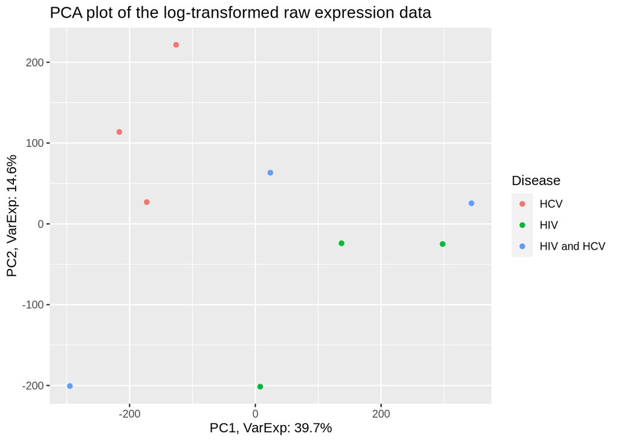

```r
exp_raw <- log2(Biobase::exprs(raw_data))

pca <- prcomp(t(exp_raw), scale. = FALSE)

percentVar <- round(100*pca$sdev^2/sum(pca$sdev^2),1)

sd_ratio <- sqrt(percentVar[2] / percentVar[1])

pca_data <- data.frame(PC1 = pca$x[,1], PC2 = pca$x[,2],
                       Disease = pData(raw_data)$Characteristics.infect.,
                    Subject = pData(raw_data)$Source.Name)

ggplot(pca_data, aes(PC1, PC2)) + geom_point(aes(colour = Disease)) +
  ggtitle("PCA plot of the log-transformed raw expression data") +
  xlab(paste0("PC1, VarExp: ", percentVar[1], "%")) +
  ylab(paste0("PC2, VarExp: ", percentVar[2], "%"))
```

The elements show that there is major variability along the first PC, as it accounts for 39.7%. We can notice some sort of clustering of samples from subjects suffering from the same type of infection. The following barplot showcases how the variability is distributed among the different PCs.

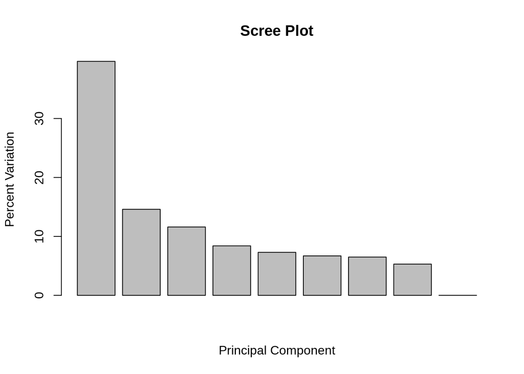

```r
barplot(percentVar, main ="Scree Plot", xlab = "Principal Component", ylab = "Percent Variation")
```

## Boxplot of log2-intensities

We could represent our probe intensities with a boxplot, with one box for each microarray in order to assess the variability in intensities.

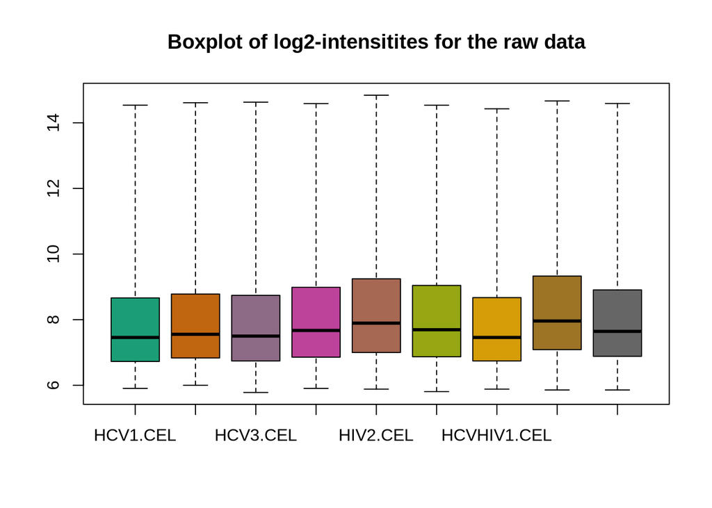

```r
oligo::boxplot(raw_data, target = "core",
               main = "Boxplot of log2-intensitites for the raw data")
```

## Background adjustment and calibration

**Backgroud Adjustment**

After we imported the data and did some initial quality assessment, we should now do some background adjustment to account for measured probe intensities that are due to non-specific binding and the noise caused by the optical detection system. All the observed intensities have to be adjusted to give accurate measurments of specific hybridization.

**Across-array normalization**

For the measurements to be comparable we need to do normalization across all arrays. This is done to account for obscuring sources of variation like different efficiencies of reverse transcription, labeling or hybridization reactions, physical with the array chips, batch effects and experimental lab conditions.

**Summarization**

We could now use the normalized data to summarize it into individual intensities for single gene transcripts. Transcripts on the affymetrix platform are represented by multiple probes, and hence multiple locations on the array. And so we now have to use the background-adjusted and normalized probe intensities and summarize it into one quantity that estimates and amount proportional to the amount of the RNA transcript.

The summarized data could be annotated with various information like the gene symbols or ENSEMBL gene ids. For our pipeline we could use the hugene10sttranscriptcluster packaged database. This package provides a mapping from the transcript cluster ids to annotation data.

We run the RMA algorithm for Background correction without normalizing the data.

```r
bgc_eset <- oligo::rma(raw_data, target = "core", normalize = FALSE)
```

```
## Background correcting
## Calculating Expression
```

```r
head(Biobase::exprs(bgc_eset), 5)
```

```
##         HCV1.CEL HCV2.CEL HCV3.CEL HIV1.CEL  HIV2.CEL HIV3.CEL HCVHIV1.CEL
## 7892501 6.515721 4.316300 4.801029 4.292536  6.684737 4.654783    4.450669
## 7892502 6.629642 6.056715 7.519840 6.719068  8.423861 7.325759    6.853616
## 7892503 4.016348 3.930736 3.702747 3.970071  3.972547 4.032644    3.655549
## 7892504 9.394528 8.843178 9.051490 9.986787 10.239148 9.814965    8.840134
## 7892505 6.100162 5.754143 5.453327 5.911795  6.234525 5.481774    5.330774
##         HCVHIV2.CEL HCVHIV3.CEL
## 7892501    5.517112    5.264861
## 7892502    7.909908    7.424468
## 7892503    3.915776    4.107153
## 7892504    9.902665    9.675756
## 7892505    6.836094    6.075377
```

## Relative Log Expression

We perform RLE by calculating the median log2 intensity of every transcript across all arrays by calculating the row medians. We could then use the sweep function to subtract the row medians from every transcript. We plot the data to highlight major differences.

```r
row_medians <- Biobase::rowMedians(as.matrix(Biobase::exprs(bgc_eset)))

RLE_data <- sweep(Biobase::exprs(bgc_eset), 1, row_medians)

RLE_data <- as.data.frame(RLE_data)

head(RLE_data)
```

```
##            HCV1.CEL    HCV2.CEL   HCV3.CEL   HIV1.CEL    HIV2.CEL    HIV3.CEL
## 7892501  1.71469159 -0.48472911  0.0000000 -0.5084929 1.883708184 -0.14624662
## 7892502 -0.69611751 -1.26904462  0.1940807 -0.6066914 1.098102276  0.00000000
## 7892503  0.04627705 -0.03933511 -0.2673242  0.0000000 0.002475403  0.06257284
## 7892504 -0.28122819 -0.83257886 -0.6242661  0.3110308 0.563391914  0.13920883
## 7892505  0.18836659 -0.15765178 -0.4584679  0.0000000 0.322729932 -0.43002069
## 7892506 -0.39380977 -0.76754519  0.1376202 -0.2409930 0.696855019  0.23956041
##         HCVHIV1.CEL HCVHIV2.CEL HCVHIV3.CEL
## 7892501  -0.3503607  0.71608284  0.46383197
## 7892502  -0.4721433  0.58414880  0.09870849
## 7892503  -0.3145222 -0.05429511  0.13708186
## 7892504  -0.8356230  0.22690835  0.00000000
## 7892505  -0.5810204  0.92429864  0.16358163
## 7892506  -1.5422070  0.09415989  0.00000000
```

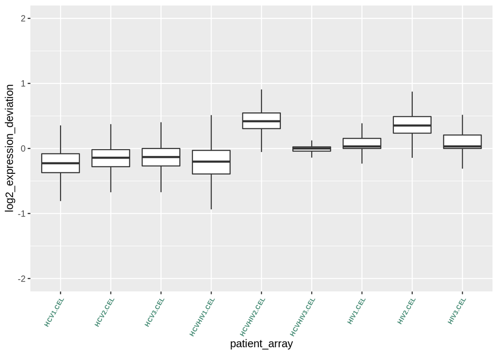

```r
RLE_data_gathered <- tidyr::gather(RLE_data, patient_array, log2_expression_deviation)

ggplot2::ggplot(RLE_data_gathered, aes(patient_array, log2_expression_deviation)) +
  geom_boxplot(outlier.shape = NA) +
  ylim(c(-2, 2)) +
  theme(axis.text.x = element_text(colour = "aquamarine4",
                                  angle = 60, size = 6.5, hjust = 1 ,
                                  face = "bold"))
```

The y-axis here shows the deviation of expression intensity from the median intensity. The boxes shifted along the y-direction indicate higher deviation. We could mark-out smaples with high deviation and keep them in mind when doing heatmap cluster analysis.

### Full RMA

We run the full RMA algorithm on our raw data, BG correcting, Normalizing and Summarizing the corrected expression values.

```r
norm_data <- oligo::rma(raw_data, target = "core")
```

```
## Background correcting
## Normalizing
## Calculating Expression
```

The normalized data looks like the following

```r
head(Biobase::exprs(norm_data), 5)
```

```
##         HCV1.CEL HCV2.CEL HCV3.CEL HIV1.CEL HIV2.CEL HIV3.CEL HCVHIV1.CEL
## 7892501 6.840320 4.621911 5.040349 4.295761 6.374089 4.741450    4.747568
## 7892502 7.020765 6.361189 7.836125 6.721096 8.037283 7.386229    7.158324
## 7892503 4.301704 4.190467 3.908013 3.960512 3.659727 4.054107    3.970850
## 7892504 9.679195 9.103843 9.301558 9.947054 9.871862 9.731855    9.199155
## 7892505 6.407047 6.010833 5.699466 5.897668 5.816928 5.506059    5.606868
##         HCVHIV2.CEL HCVHIV3.CEL
## 7892501    5.065219    5.226656
## 7892502    7.602965    7.592462
## 7892503    3.510044    4.183265
## 7892504    9.522180    9.800482
## 7892505    6.374732    6.124323
```

### Quality Assesment of calibrated data using PCA

Now that we have the RMA-calibrated data we could perform another PCA and produce a clustering heatmap. This would help us see how normalizing and transforming the data greatly affects the analysis and the kind of insights we could extract.

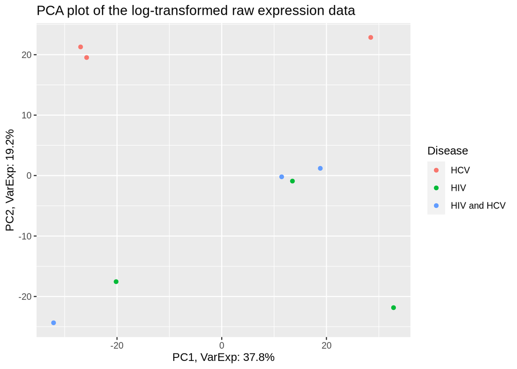

```r
normalized_exp <- Biobase::exprs(norm_data)

pca <- prcomp(t(normalized_exp), scale. = FALSE)

percentVar <- round(100*pca$sdev^2/sum(pca$sdev^2),1)

sd_ratio <- sqrt(percentVar[2] / percentVar[1])

pca_data <- data.frame(PC1 = pca$x[,1], PC2 = pca$x[,2],
                        Disease =  Biobase::pData(norm_data)$Characteristics.infect.,
                    Subject = pData(raw_data)$Source.Name)

ggplot(pca_data, aes(PC1, PC2), label = TRUE) + geom_point(aes(colour = Disease)) +
  ggtitle("PCA plot of the log-transformed raw expression data") +
  xlab(paste0("PC1, VarExp: ", percentVar[1], "%")) +
  ylab(paste0("PC2, VarExp: ", percentVar[2], "%"))
```

## Heat Map

We first set up the variables for the pheatmap function into a dataframe.

```r
infection_type <- pData(norm_data)$Characteristics.infect.

#Heat map wi;; be annotated with the types of infection to help visualize
annotation_for_heatmap <- data.frame(Infection = infection_type)

row.names(annotation_for_heatmap) <- row.names(pData(norm_data))
```

Now we could generate a heatmap to better see the distance differences among the samples and identify clusters.

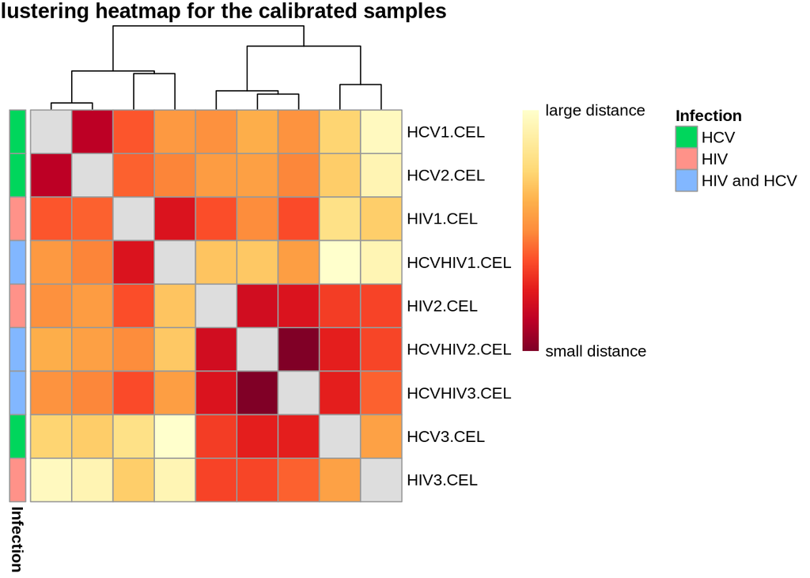

```r
dists <- as.matrix(dist(t(normalized_exp)))

rownames(dists) <- row.names(pData(norm_data))

heatmap_col <- rev(colorRampPalette(RColorBrewer::brewer.pal(9, "YlOrRd"))(255))

colnames(dists) <- NULL

diag(dists) <- NA

ann_colors <- list(
  Infected = c(HIVHCV = "blue4", HIV = "cadetblue2", HCV = "burlywood3"))

pheatmap(dists, col = (heatmap_col),
         annotation_row = annotation_for_heatmap,
         annotation_colors = ann_colors,
         legend = TRUE,
         treeheight_row = 0,
         legend_breaks = c(min(dists, na.rm = TRUE),
                         max(dists, na.rm = TRUE)),
         legend_labels = (c("small distance", "large distance")),
         main = "Clustering heatmap for the calibrated samples")
```

The clustering shows relatively small distances between HIV mono-infected and HIV/HCV co-infected individuals in contrast to HCV mono-infected individuals. The following table shows the different expression profiles between the three groups.

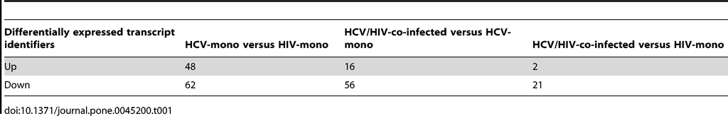

We can see that HIV mono-infected subjects and co-infected subjects have similar expression patterns and hence low DGE count, which is highlighted by the clustering on the map by very small distances between those samples.

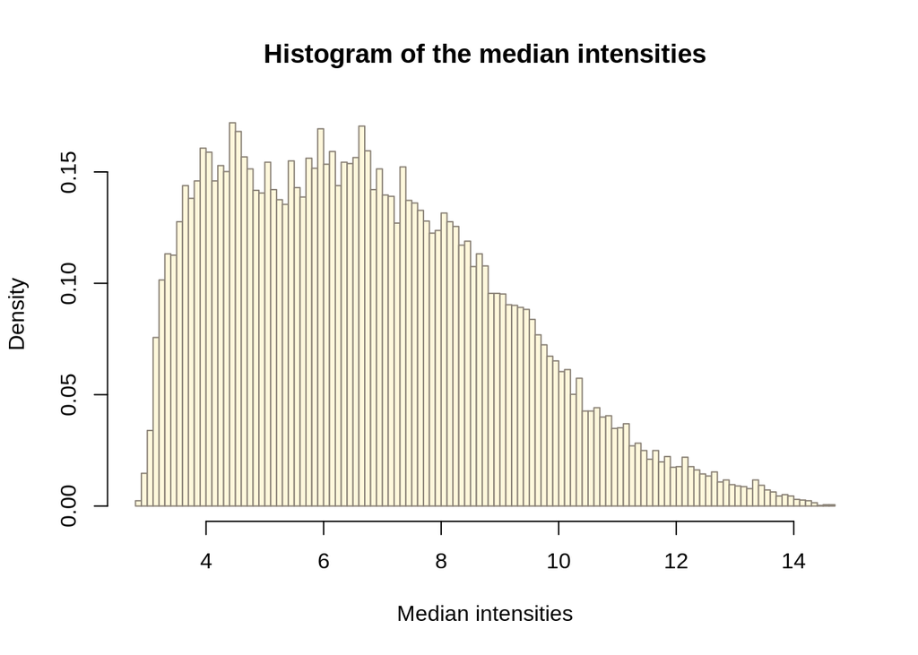

```r
medians <- rowMedians(Biobase::exprs(norm_data))

hist_res <- hist(medians, 100, col = "cornsilk1", freq = FALSE,
            main = "Histogram of the median intensities",
            border = "antiquewhite4",
            xlab = "Median intensities")
```

## Filtering low intensity values

The study did not mention anything about filtering out low intensity probes that have high frequency. So I will leave this for now. I will just highlight a possible cut off value based on the data distribution.

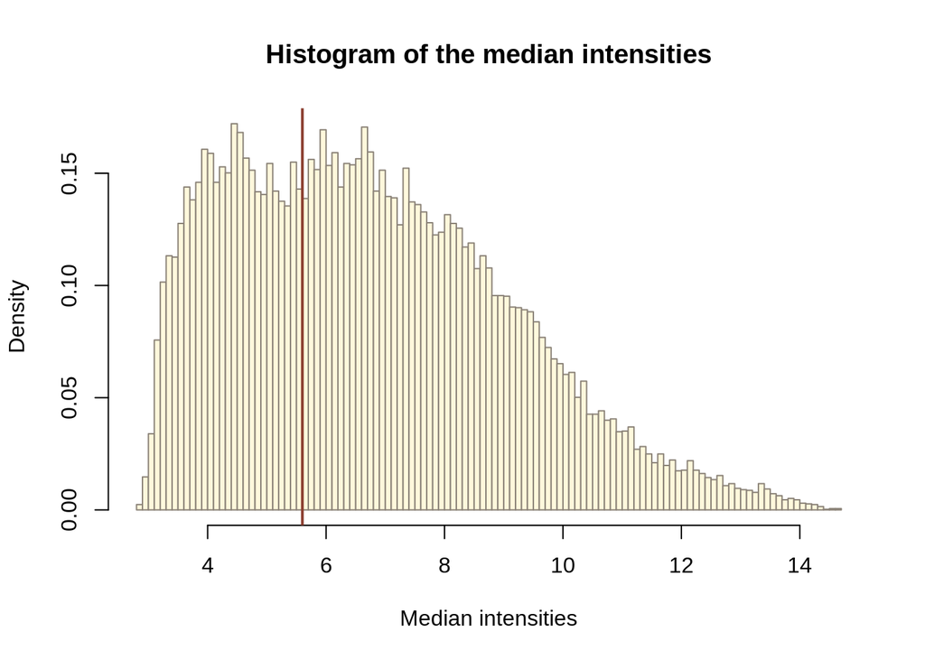

```r
man_threshold <- 5.6

hist_res <- hist(medians, 100, col = "cornsilk", freq = FALSE,
            main = "Histogram of the median intensities",
            border = "antiquewhite4",
            xlab = "Median intensities")

abline(v = man_threshold, col = "coral4", lwd = 2)
```

## Annotation

We add feature data to identify which transcript clusters refer to which genes.

```r
annotated_probes <- AnnotationDbi::select(hugene10sttranscriptcluster.db,
                                  keys = (featureNames(norm_data)),
                                  columns = c("SYMBOL", "GENENAME"),
                                  keytype = "PROBEID")
annotated_probes <- subset(annotated_probes, !is.na(SYMBOL))

head(annotated_probes, 5)
```

```
##      PROBEID      SYMBOL
## 4204 7896740       OR4F4
## 4205 7896740      OR4F17
## 4206 7896740       OR4F5
## 4207 7896742 LINC00266-1
## 4208 7896742      PCMTD2
##                                                                          GENENAME
## 4204                             olfactory receptor family 4 subfamily F member 4
## 4205                            olfactory receptor family 4 subfamily F member 17
## 4206                             olfactory receptor family 4 subfamily F member 5
## 4207                                 long intergenic non-protein coding RNA 266-1
## 4208 protein-L-isoaspartate (D-aspartate) O-methyltransferase domain containing 2
```

## Removing multiple mappings to the same gene

We now have to remove probesets mapping to multiple genes. And so we see how many matches each probe has with distinct gene symbols.

```r
grouped_annotations <- group_by(annotated_probes, PROBEID)

summarized_annotations <- dplyr::summarize(grouped_annotations, no_of_matches = n_distinct(SYMBOL))
head(summarized_annotations)
```

```
## # A tibble: 6 x 2
##   PROBEID no_of_matches
##   <chr>           <int>
## 1 7896740             3
## 2 7896742             3
## 3 7896744             4
## 4 7896754             1
## 5 7896756             2
## 6 7896759             1
```

We only select those who have more than one match per gene by extracting them from the summarized annotation.

```r
filtered_annotation <- filter(summarized_annotations, no_of_matches > 1)
head(filtered_annotation)
```

```
## # A tibble: 6 x 2
##   PROBEID no_of_matches
##   <chr>           <int>
## 1 7896740             3
## 2 7896742             3
## 3 7896744             4
## 4 7896756             2
## 5 7896937             3
## 6 7896961             3
```

Now we have the number of probes that map to multiple genes and their corresponding IDs.

```r
probe_stats <- filtered_annotation
nrow(probe_stats)
```

```
## [1] 2194
```

We extract the IDs of the probes we want to remove.

```r
ids_to_exclude <- (featureNames(norm_data) %in% probe_stats$PROBEID)

table(ids_to_exclude)
```

```
## ids_to_exclude
## FALSE  TRUE
## 31103  2194
```

And finally generate an expression set with no duplicates.

```r
filtered_final_eset <- subset(norm_data, !ids_to_exclude)
validObject(filtered_final_eset)
```

```
## [1] TRUE
```

```r
head(Biobase::exprs(filtered_final_eset), 3)
```

```
##         HCV1.CEL HCV2.CEL HCV3.CEL HIV1.CEL HIV2.CEL HIV3.CEL HCVHIV1.CEL
## 7892501 6.840320 4.621911 5.040349 4.295761 6.374089 4.741450    4.747568
## 7892502 7.020765 6.361189 7.836125 6.721096 8.037283 7.386229    7.158324
## 7892503 4.301704 4.190467 3.908013 3.960512 3.659727 4.054107    3.970850
##         HCVHIV2.CEL HCVHIV3.CEL
## 7892501    5.065219    5.226656
## 7892502    7.602965    7.592462
## 7892503    3.510044    4.183265
```

We now add a column to our new Expression Set called PROBEID to match it later with the feature data.

```r
fData(filtered_final_eset)$PROBEID <- rownames(fData(filtered_final_eset))
```

We have to also filter the feature data from the annotated_probes. We use a left-join, which takes the rows and columns from our filtered expression set and adds to it only the corresponding column entries from the annotated_probes, thereby filtering it.

```r
fData(filtered_final_eset) <- left_join(fData(filtered_final_eset), annotated_probes)
rownames(fData(filtered_final_eset)) <- fData(filtered_final_eset)$PROBEID
validObject(filtered_final_eset)
```

```
## [1] TRUE
```

## Constructing Design Matrices

We now have to construct design matrices for our models. These will serve in t-testing and linear model fitting in the Emperical Bayes

```r
subjects <- Biobase::pData(filtered_final_eset)$Source.Name

infection <- Biobase::pData(filtered_final_eset)$Characteristics.infect.
```

The main design matrix contains dummy variables that will act as our on and off switches in model fitting.

```r
main_design_mat <- model.matrix(~ 0 + infection)
rownames(main_design_mat) <- subjects
colnames(main_design_mat) <- c("HCV", "HIV", "HIVHCV")
```

For every subject, the design value matrix 1 corresponds to the type of infection for that subject.

```r
head(main_design_mat)
```

```
##       HCV HIV HIVHCV
## HCV-1   1   0      0
## HCV-2   1   0      0
## HCV-3   1   0      0
## HIV-1   0   1      0
## HIV-2   0   1      0
## HIV-3   0   1      0
```

Since we want to compare expression values between pairs of samples we will construct other design matrices accordingly and take data subsets for later analysis.

```r
design_mat_monoInfected <- main_design_mat[1:6,1:2]
design_mat_monoInfected
```

```
##       HCV HIV
## HCV-1   1   0
## HCV-2   1   0
## HCV-3   1   0
## HIV-1   0   1
## HIV-2   0   1
## HIV-3   0   1
```

## DGE Analysis Based on One Gene

We now aim to see expression differences between HIV and HCV infected individuals for a single gene,the EPHA4 gene for EPH receptor A4.  
We first extract the expression data from the filtered expression set for EPHA4 and then set it up as a Data Frame.

```r
exprs_epha4 <- Biobase::exprs(filtered_final_eset)["8059279",]

epha4_data <- as.data.frame(exprs_epha4)

colnames(epha4_data) <- "Expression"
```

Our EPHA4 data now has only expression values for now. We use mutate to add the subjects and the type of infection they have.

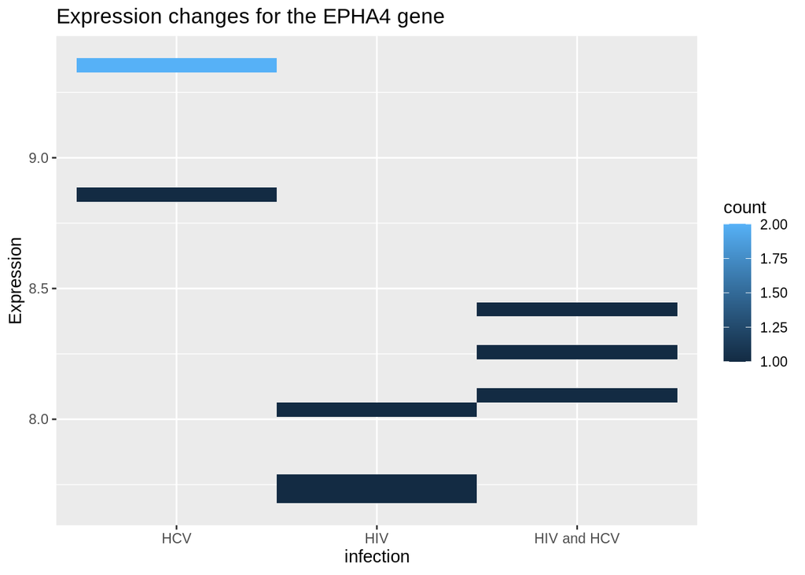

```r
colnames(epha4_data)[1] <- "Expression"

epha4_data <- mutate(epha4_data, subject = subjects, infect = infection)


ggplot(data = epha4_data, aes(x = infection, y = Expression,
                             group = infection, color = subjects)) +
      geom_bin2d() +
      ggtitle("Expression changes for the EPHA4 gene")
```

The results of the study show very different expression patterns in the EPHA4 when comparing HCV with HIV mono-infected individuals and co-infected ones. The preceding plot highlights this difference in expression.  
We can now fit a linear model for EPHA4 expression data.

```r
epha4_coef <- lmFit(filtered_final_eset,
                design = main_design_mat)$coefficients["8059279",]


epha4_coef
```

```
##      HCV      HIV   HIVHCV
## 9.196842 7.834149 8.257029
```

We can calculate the fitted values by using the coefficient and the design matrix.

```r
epha4_fitted <- main_design_mat %*% epha4_coef
```

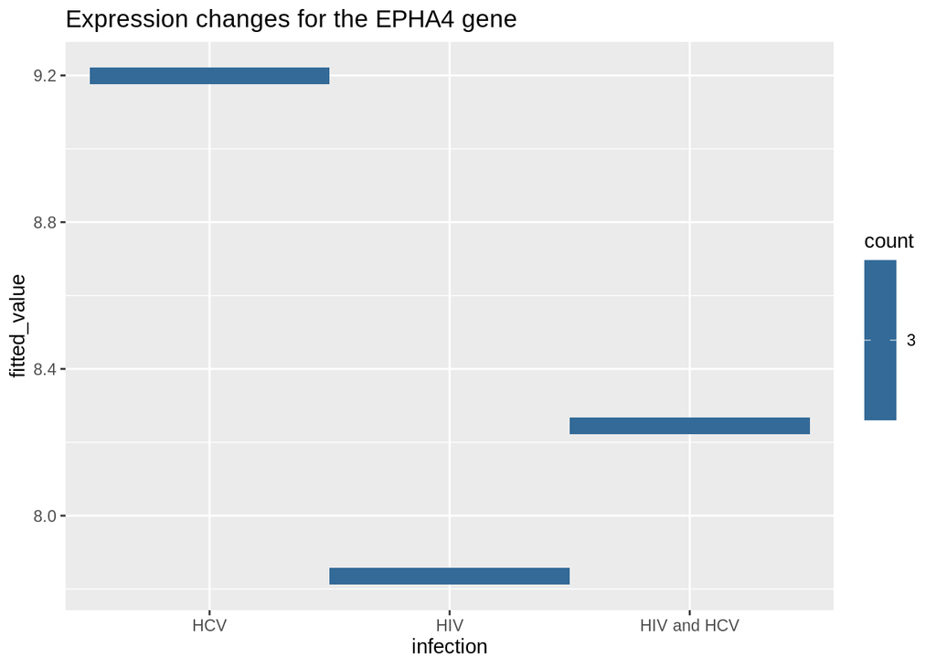

```r
epha4_data$fitted_value <- epha4_fitted


ggplot(data = epha4_data, aes(x = infection, y = fitted_value,
                             group = infection, color = subjects)) +
      geom_bin2d() +
      ggtitle("Expression changes for the EPHA4 gene")
```

## Contrasts and Hypthesis testing

We now can find the genes with significant differential expression by creating a contrast matrix and using it in a linear model within Empirical Bayes.

```r
contrast_mat <- makeContrasts(HIV-HCV, levels = main_design_mat)
```

```r
mono_fit <- eBayes(contrasts.fit(lmFit(filtered_final_eset,
                                design = main_design_mat),
                                contrast_mat))
```

Generating a table with the deferentially expressed genes.

```r
table <- topTable(mono_fit, number = Inf)
head(table, 20)
```

```
##         PROBEID   SYMBOL
## 7895507 7895507     <NA>
## 8156610 8156610    HABP4
## 8164343 8164343  FAM102A
## 7942989 7942989     <NA>
## 8059279 8059279    EPHA4
## 8030339 8030339   FLT3LG
## 8156026 8156026    CEP78
## 8124518 8124518   H2AC14
## 7978360 7978360     GZMH
## 8094240 8094240     CD38
## 8142110 8142110    SYPL1
## 7894818 7894818     <NA>
## 8102848 8102848    SETD7
## 8068713 8068713      MX1
```

[output cut: 48 more lines]

The study chose a p-value cut off of 0.05 and a Fold Change cut off of 2. We must filter our data as such and take a subset of the DEGs that match the constraints.

```r
DEG_table <- subset(table, P.Value < 0.05)
DEG_table <- subset(DEG_table,  abs(logFC) > 1)
nrow(DEG_table)
```

```
## [1] 124
```

```r
View(DEG_table)
```

```r
library(xlsx)
write.xlsx(DEG_table, file = "DEG_results.xlsx",
      sheetName = "Differential Gene Expression Mono-Infected", append = FALSE)
```

We can now see how our p-values are distributed among the DEGs.

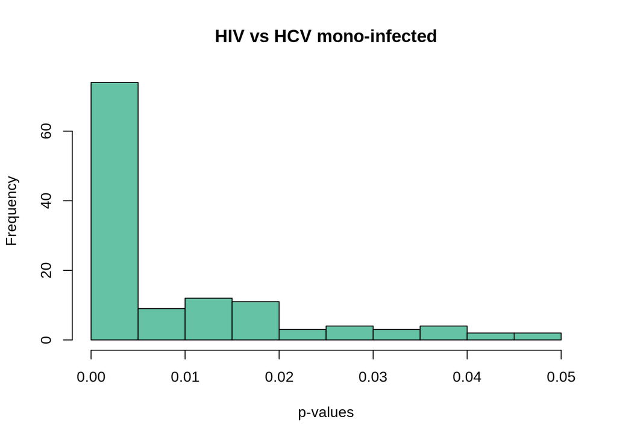

```r
hist(DEG_table$P.Value, col = brewer.pal(3, name = "Set2")[1],
     main = "HIV vs HCV mono-infected", xlab = "p-values")
```

A volcano plot helps us see the differentially expressed genes. The plot shows the DEGs on the extremities of the plot, hence DEGs with very low p-values and high fold-change.

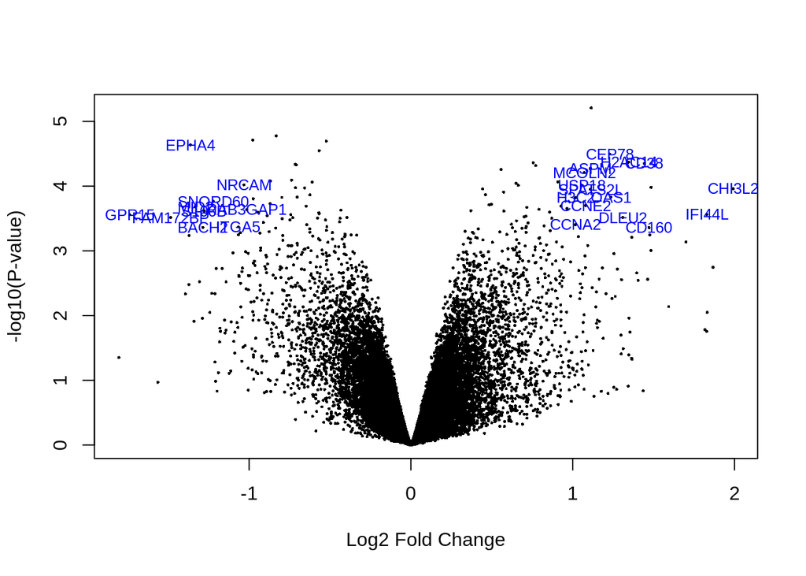

```r
volcano_names <- ifelse(abs(mono_fit$coefficients)>=1,
                        mono_fit$genes$SYMBOL, NA)


volcanoplot(mono_fit, coef = 1L, style = "p-value", highlight = 100,
            names = volcano_names,
            xlab = "Log2 Fold Change", ylab = NULL, pch=16, cex=0.35)
```

We import the results provided by the paper and compare the numbers of deferentially expressed genes.

```r
paper_DEG_data <- read.xlsx("paper_DEGs.XLS",1)

colnames(paper_DEG_data) <- c("TranscriptID", "Gene", "RefSeq.", "P-value", "Fold Change")

head(paper_DEG_data)
```

```
##   TranscriptID   Gene      RefSeq.     P-value Fold Change
## 1      8074606  USP18    NM_017414 1.18865e-05     2.80180
## 2      7895507   <NA>          --- 6.24888e-05     2.16508
## 3      8059279  EPHA4    NM_004438 2.44771e-04    -2.57170
## 4      8156026  CEP78 NM_001098802 2.99672e-04     2.34298
## 5      7917283 MCOLN2    NM_153259 4.71836e-04     2.10106
## 6      7923086   ASPM    NM_018136 4.26665e-04     2.15643
```

In order to compare the number of DEGs we will load them as lists of either TranscriptIDs or Gene identifiers.

```r
paper_DEG_list <- paper_DEG_data$Gene
paper_DEG_list <- paper_DEG_list[!is.na(paper_DEG_list)]

our_DEG_list <- DEG_table$SYMBOL
our_DEG_list <- our_DEG_list[!is.na(our_DEG_list)]
```

We get the ratio of our results to the paper’s. Since we removed some NA values, some of the matches got discarded.

```r
overlap <- length(intersect(our_DEG_list, paper_DEG_list)) / length(paper_DEG_list)
overlap
```

```
## [1] 0.8271605
```

We could just compare by ProbeID. Which makes more sense since we excluded some non annotated (NA) gene symbols.

```r
paperID_DEG <- paper_DEG_data$TranscriptID
ourID_DEG <- DEG_table$PROBEID
ID_overlap <- length(intersect(ourID_DEG, paperID_DEG)) / length(paperID_DEG)
ID_overlap
```

```
## [1] 0.9818182
```

## GO Based Enrichement Analysis

```r
DEG_IDs <- DEG_table$PROBEID
```

```r
suppressWarnings(back_genes_idx <- genefilter::genefinder(filtered_final_eset,
                                        as.character(DEG_IDs),
                                        method = "manhattan", scale = "none"))
```

```r
back_genes_idx <- sapply(back_genes_idx, function(x)x$indices)
```

```r
back_genes <- featureNames(filtered_final_eset)[back_genes_idx]
back_genes <- setdiff(back_genes, DEG_IDs)


intersect(back_genes, DEG_IDs)
```

```
## character(0)
```

```r
gene_IDs <- rownames(DEG_table)
in_universe <- gene_IDs %in% c(DEG_IDs, back_genes)
in_selection <- gene_IDs %in% DEG_IDs

all_genes <- in_selection[in_universe]
all_genes <- factor(as.integer(in_selection[in_universe]))
names(all_genes) <- gene_IDs[in_universe]
```

Error in Loading GeneList all_genes. This has to be a factor with 2 levels. re evaluate the filtering process.

```r
#top_GO_Enrichement <- top_GO_data <- new("topGOdata", ontology = "BP", allGenes = all_genes, nodeSize = 10, annot = annFUN.db, affyLib = "hugene10sttranscriptcluster.db")
```

## Attempted ANOVA Analysis

```r
HIV_eset <- filtered_final_eset[,4:6]
HIV_df <- as.data.frame(Biobase::exprs(HIV_eset))
colnames(HIV_df) <- c("HIV", "HIV","HIV")
HCV_eset <- filtered_final_eset[,1:3]
HCV_df <- as.data.frame(Biobase::exprs(HCV_eset))
colnames(HCV_df) <- c("HCV", "HCV","HCV")
merged <- cbind(HIV_df, HCV_df)
head(merged)
```

```
##              HIV      HIV      HIV      HCV      HCV      HCV
## 7892501 4.295761 6.374089 4.741450 6.840320 4.621911 5.040349
## 7892502 6.721096 8.037283 7.386229 7.020765 6.361189 7.836125
## 7892503 3.960512 3.659727 4.054107 4.301704 4.190467 3.908013
## 7892504 9.947054 9.871862 9.731855 9.679195 9.103843 9.301558
## 7892505 5.897668 5.816928 5.506059 6.407047 6.010833 5.699466
## 7892506 7.534608 8.083153 7.975167 7.683847 7.287917 8.167317
```

```r
infection_levels <- gl(2,3,6, label=c("HIV", "HCV"))
aof <- function(x) {
  m <-data.frame(infection_levels, x);
  anova(aov(x ~ infection_levels, m)) }

anov_res <- apply(merged,1, aof)
```

[output not shown]

[output cut: 16 more lines]

[output not shown]

```r
anov_res[1]
```

```
## $`7892501`
## Analysis of Variance Table
##
## Response: x
##                  Df Sum Sq Mean Sq F value Pr(>F)
## infection_levels  1 0.1985 0.19848  0.1535 0.7152
## Residuals         4 5.1733 1.29333
```

```r
pvalues <-data.frame( lapply(anov_res, function(x){x["Pr(>F)"][1,]}))
pvalues_table <- t(pvalues)
colnames(pvalues_table) <- "P-Value"
```

```r
head(pvalues_table)
```

```
##             P-Value
## X7892501 0.71521978
## X7892502 0.61745276
## X7892503 0.22094837
## X7892504 0.05339394
## X7892505 0.27580583
## X7892506 0.64552762
```

Very high p-values. To re-evaluate.